# Лабораторная работа №5

Построение графиков

Ко Антон Геннадьевич

antonkosakh@gmail.com

Российский университет дружбы народов

2026-11-07

# Информация

## Докладчик

- Ко Антон Геннадьевич
- студент
- Российский университет дружбы народов им. П. Лумумбы
- 1132221551@rudn.ru
- https://SenDerMen04.github.io/ru/

## 1. Цель работы

Основная цель работы — освоить синтаксис языка Julia для построения графиков.

### 2.1 Основные пакеты для работы с графиками в Julia

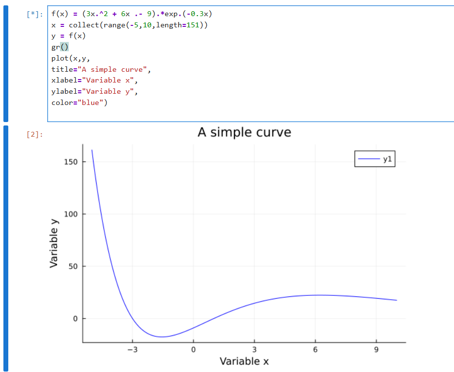

График функции, построенный при помощи gr()

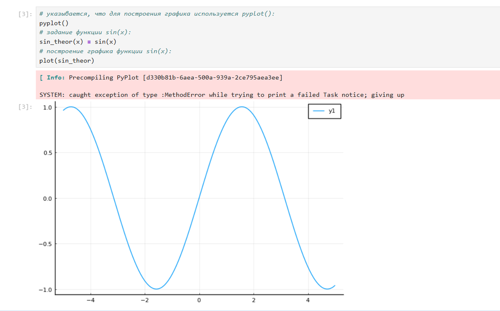

График функции, построенный при помощи pyplot()

### 2.2 Опции при построении графика

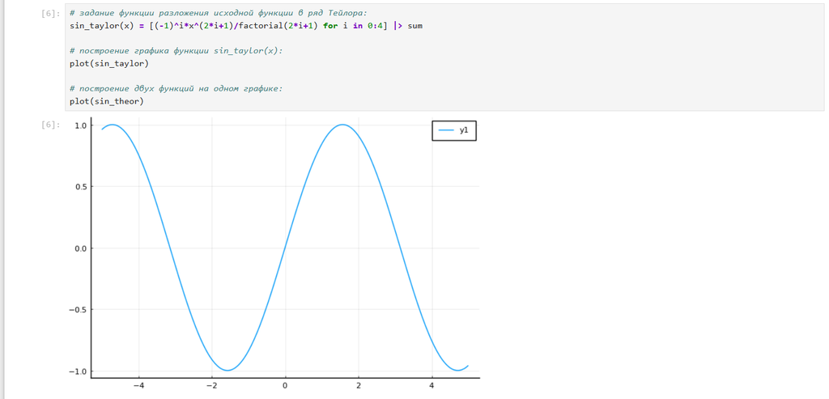

График функции sin(x)

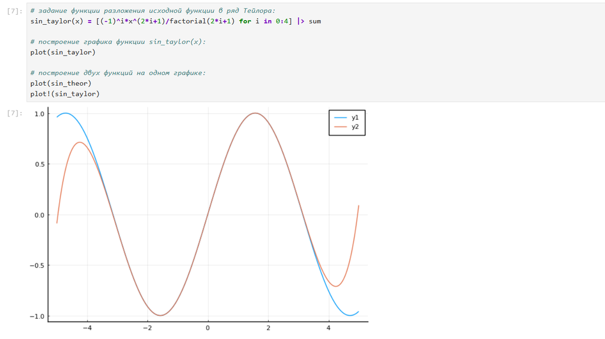

График функции разложения исходной функции в ряд Тейлора

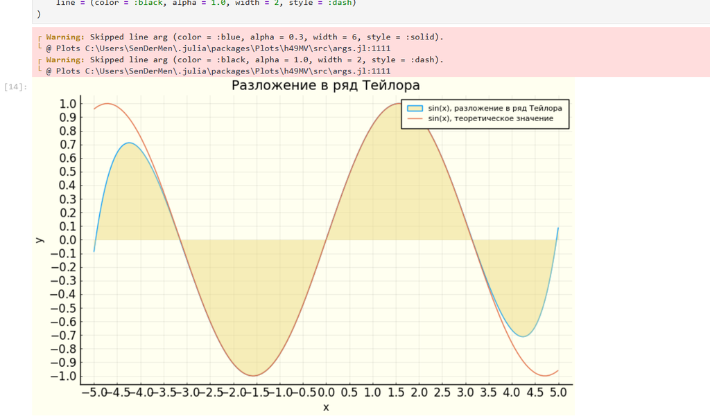

Графики исходной функции и её разложения в ряд Тейлора

[figure not shown]

### 2.3 Точечный график

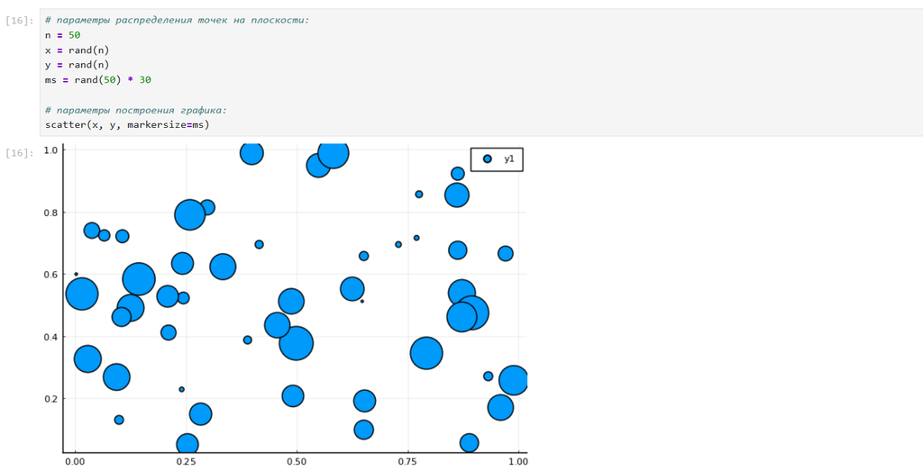

Для точечного графика можно задать различные опции, например размер маркера, его тип, цвет и т.п. (рис. #fig:008):

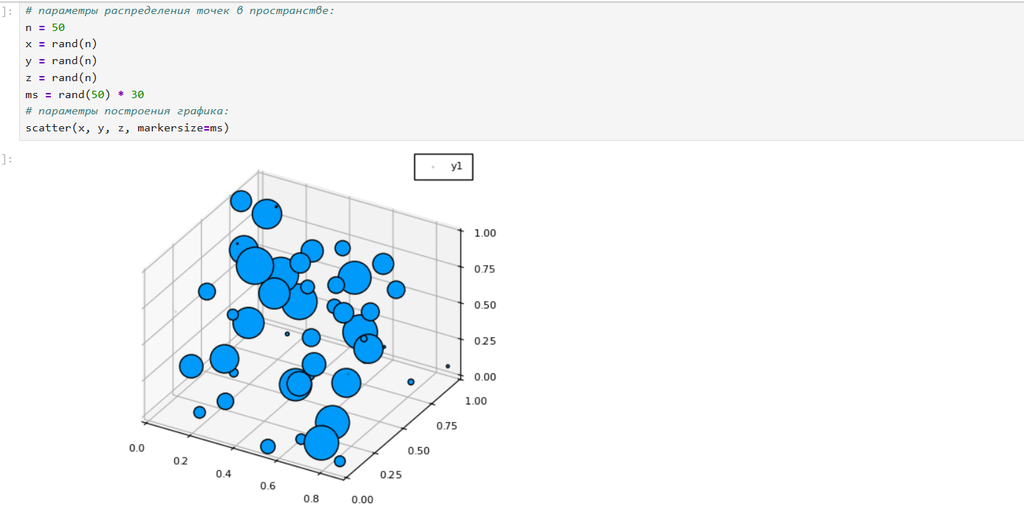

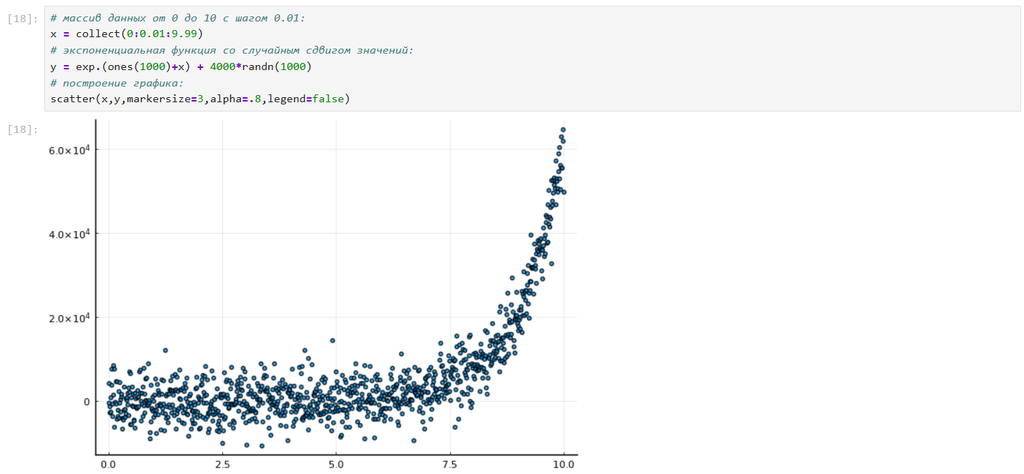

### 2.4 Аппроксимация данных

Для демонстрации зададим искусственно некоторую функцию, в данном случае похожую по поведению на экспоненту (рис. #fig:010):

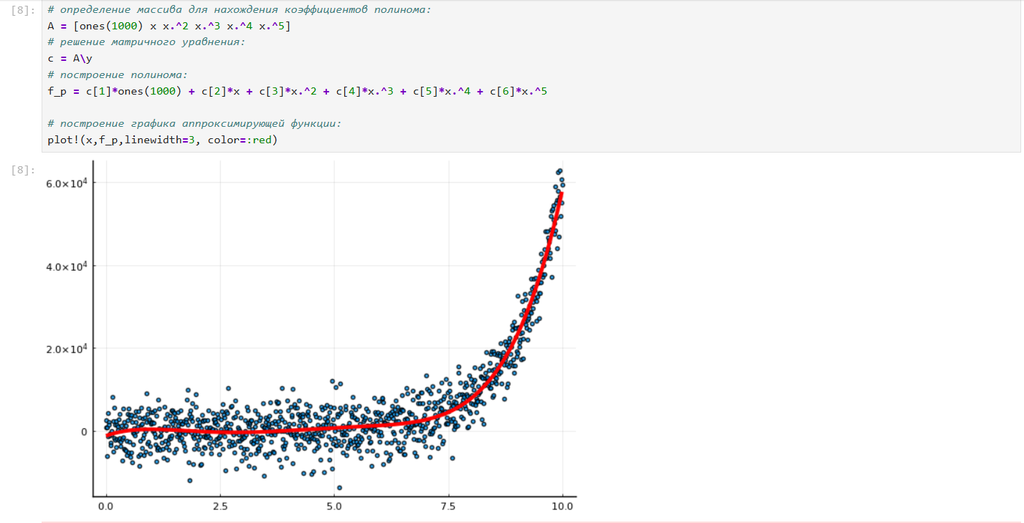

[figure not shown]

### 2.5 Две оси ординат

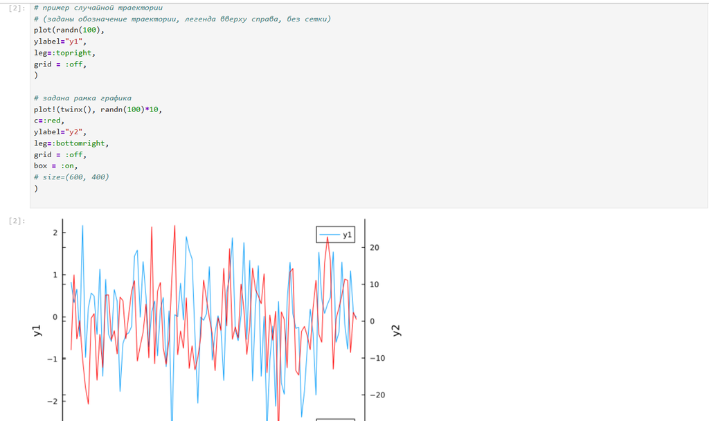

### 2.6 Полярные координаты

Приведём пример построения графика функции в полярных координатах (рис. #fig:013):

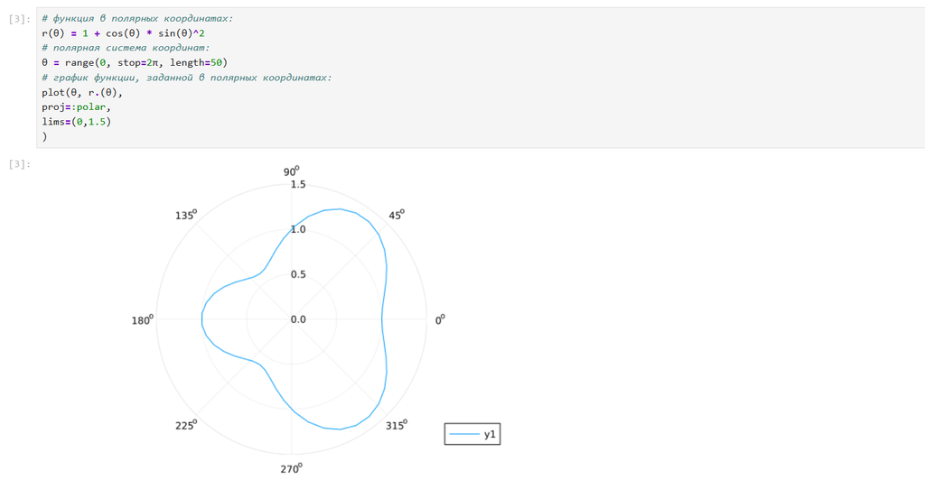

График функции, заданной в полярных координатах

### 2.7 Параметрический график

Приведём пример построения графика параметрически заданной кривой на плоскости (рис. #fig:014):

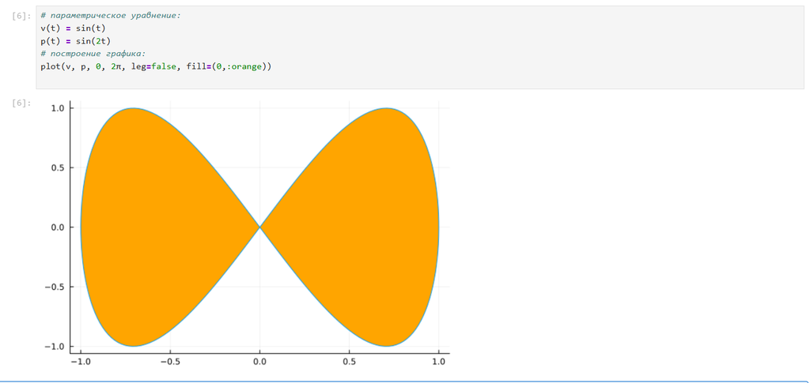

Параметрический график кривой на плоскости

Далее приведём пример построения графика параметрически заданной кривой в пространстве (рис. #fig:015):

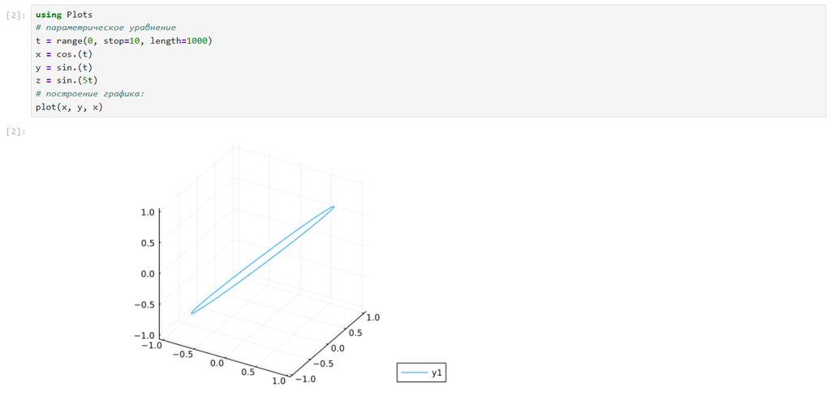

Параметрический график кривой в пространстве

### 2.8 График поверхности

Для построения поверхности, заданной уравнением f(x, y) = x² + y², можно воспользоваться функцией surface() (рис. #fig:016):

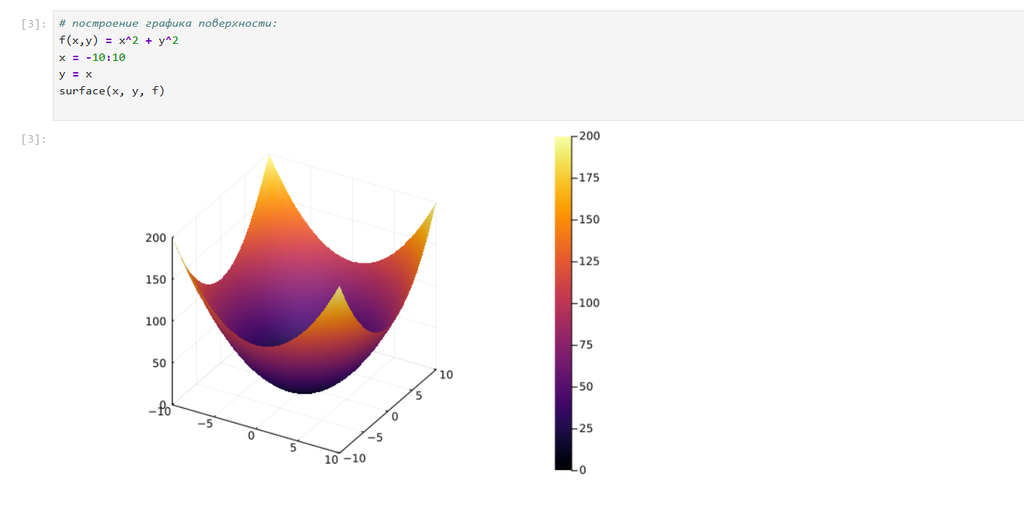

График поверхности (использована функция surface())

Также можно воспользоваться функцией plot() с заданными параметрами (рис. #fig:017):

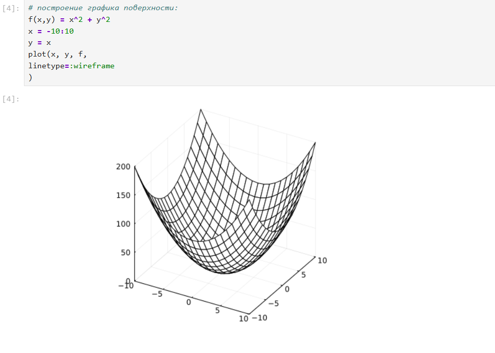

График поверхности (использована функция plot())

Можно задать параметры сглаживания (рис. #fig:018):

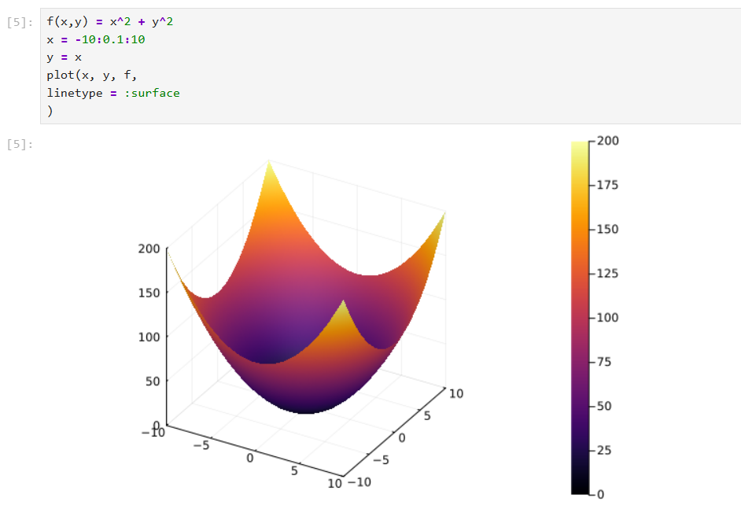

Сглаженный график поверхности

Можно задать определённый угол зрения (рис. #fig:019):

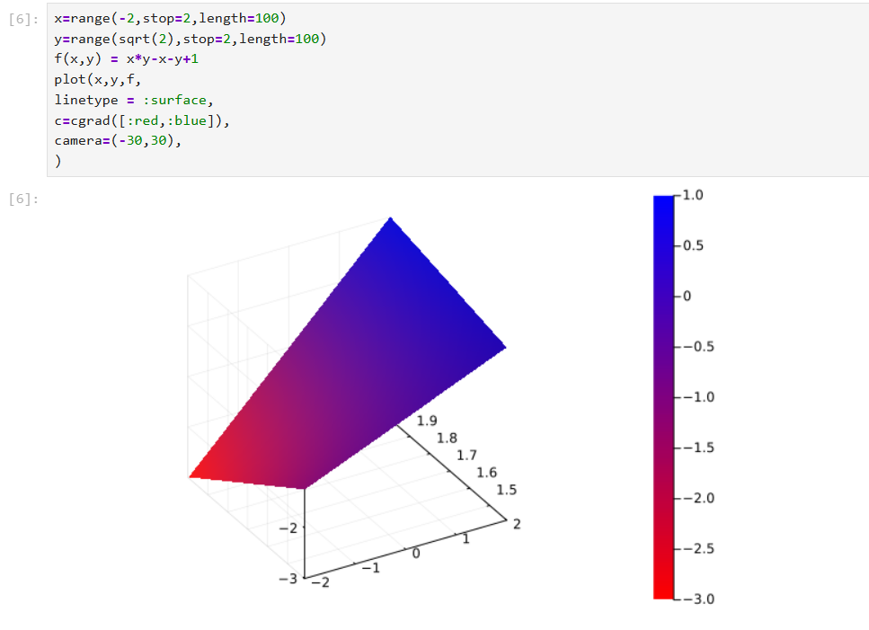

График поверхности с изменённым углом зрения

### 2.9 Линии уровня

Рассмотрим поверхность, заданную функцией g(x, y) = (3x + y²)|sin(x) + cos(y)| (рис. #fig:020):

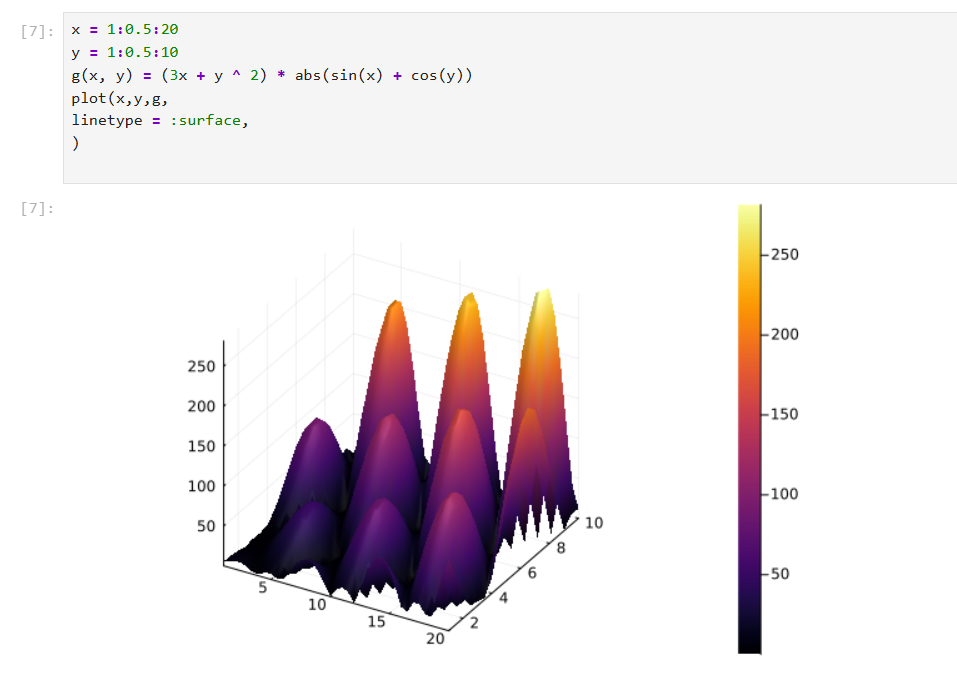

График поверхности, заданной функцией g(x, y)

Линии уровня можно построить, используя проекцию значений исходной функции на плоскость (рис. #fig:021):

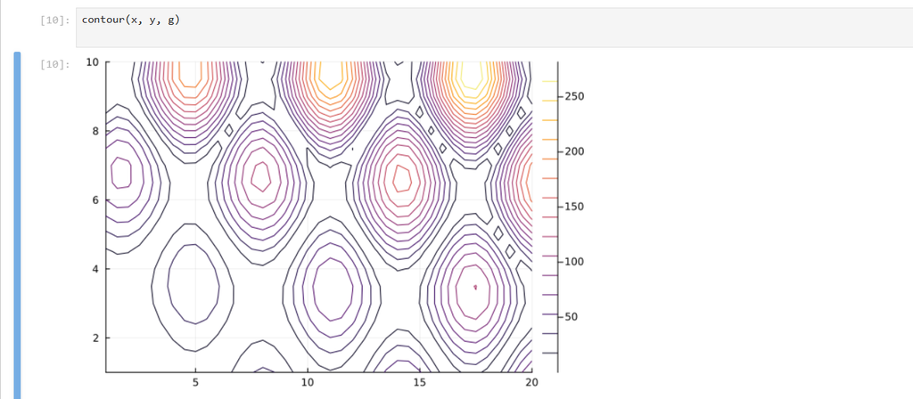

Линии уровня

Можно дополнительно добавить заливку цветом (рис. #fig:022):

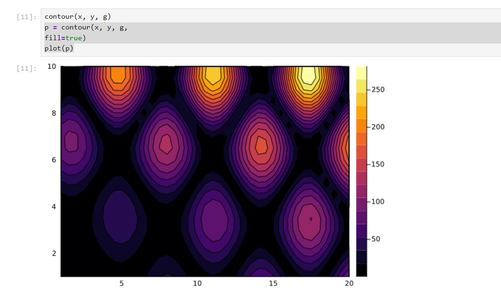

Линии уровня с заполнением

### 2.10 Векторные поля

Для функции h(x, y) = x³ – 3x + y² сначала построим её график (рис. #fig:023) и линии уровня (рис. #fig:024):

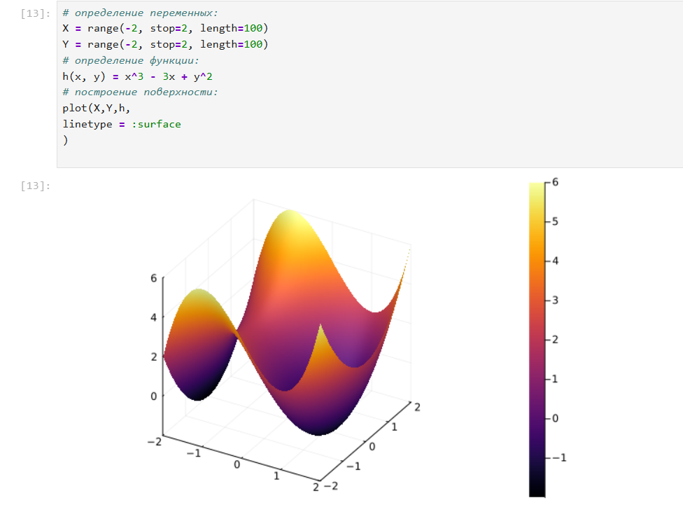

График функции h(x, y) = x³ – 3x + y²

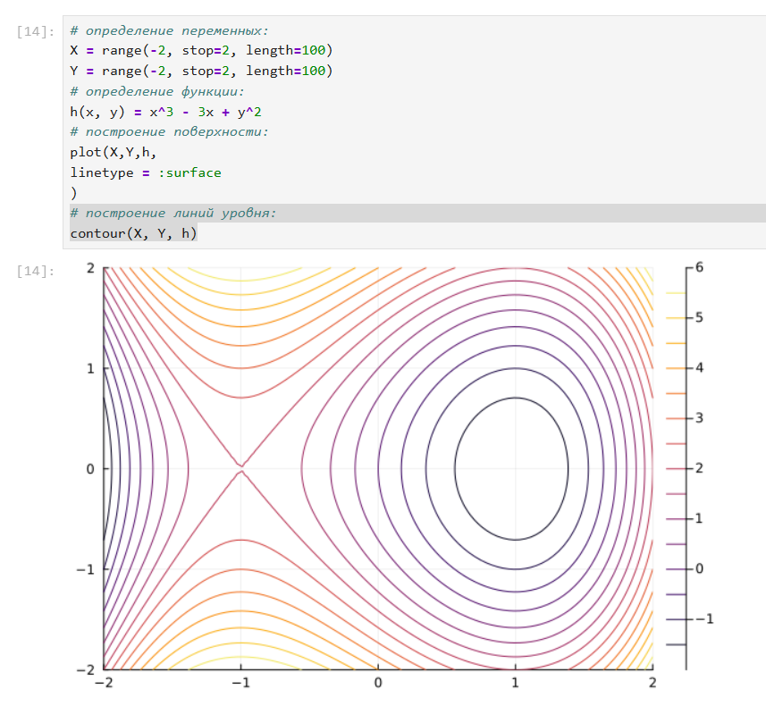

Линии уровня для функции h(x, y) = x³ – 3x + y²

### 2.11 Анимация

Строим поверхность (рис. #fig:025):

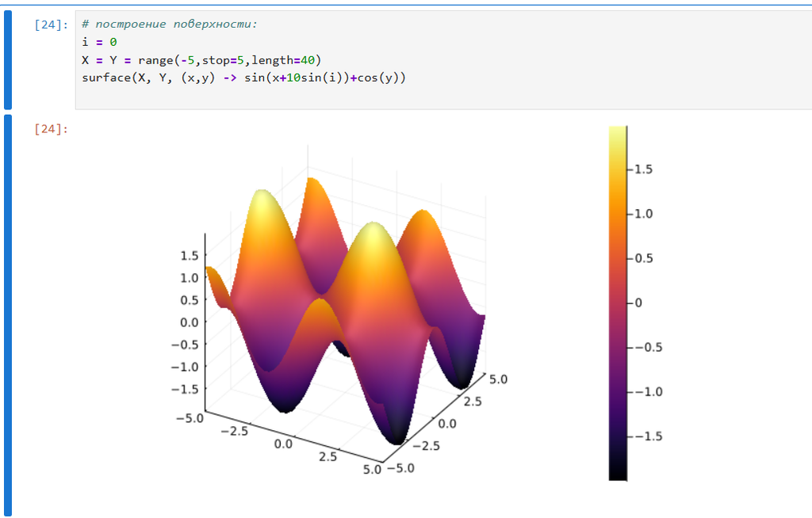

Статичный график поверхности

Добавляем анимацию (рис. #fig:026):

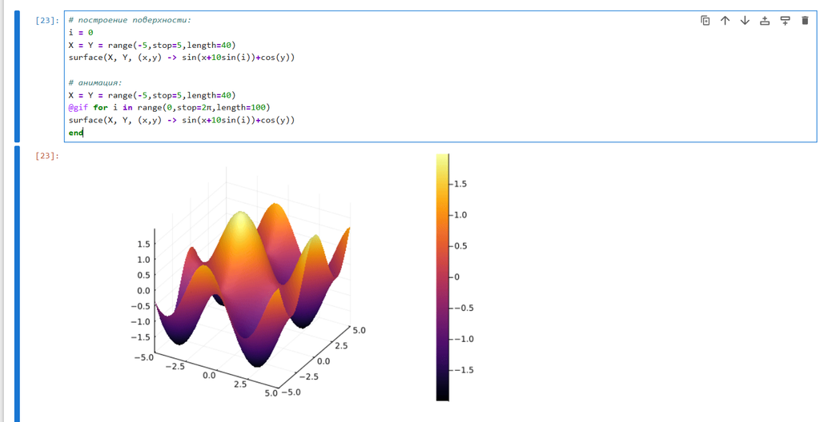

Анимированный график поверхности

### 2.12 Гипоциклоида

Построим большую окружность (рис. #fig:027):

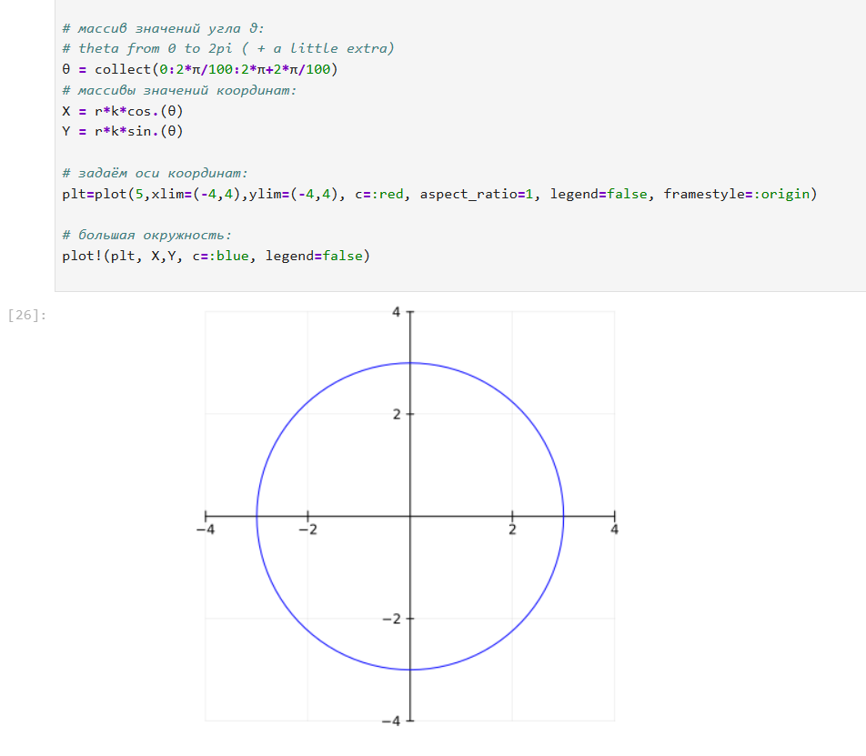

Большая окружность гипоциклоиды

Для частичного построения гипоциклоиды будем менять параметр t (рис. #fig:028):

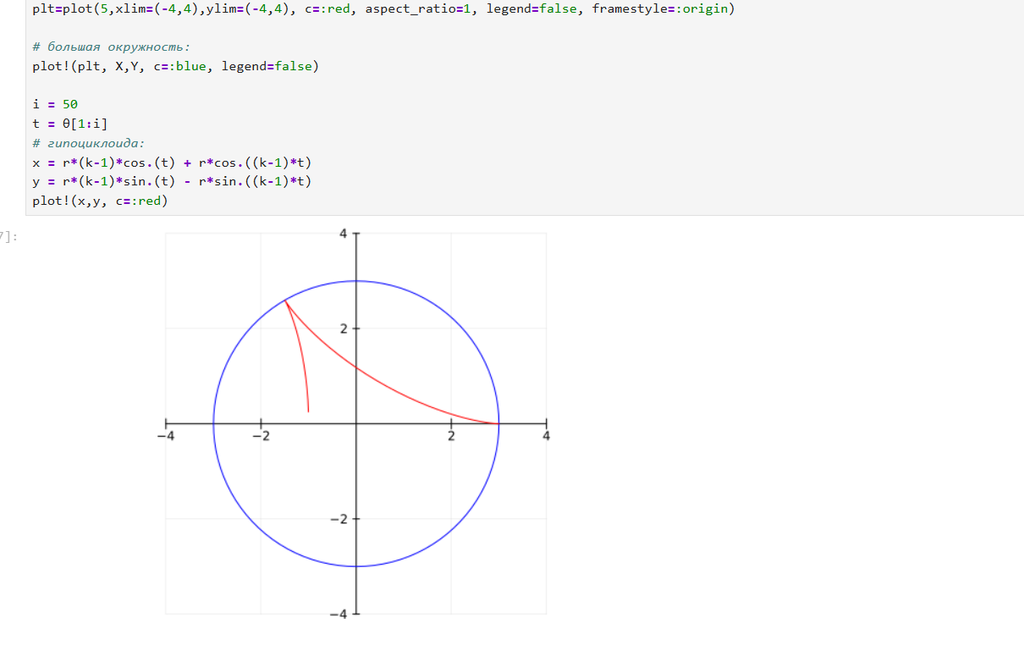

Половина пути гипоциклоиды

Добавляем малую окружность гипоциклоиды (рис. #fig:029):

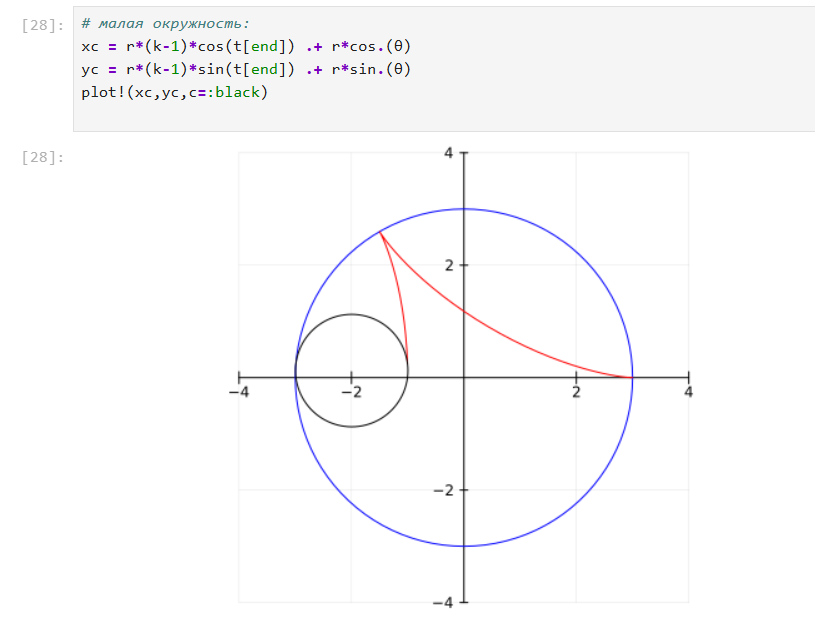

Малая окружность гипоциклоиды

Добавим радиус для малой окружности (рис. #fig:030):

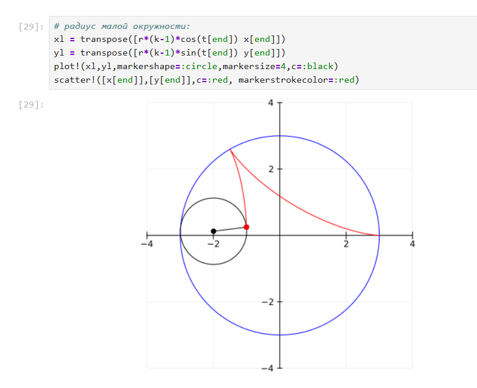

Малая окружность гипоциклоиды с добавлением радиуса

В конце сделаем анимацию получившегося изображения (рис. #fig:031):

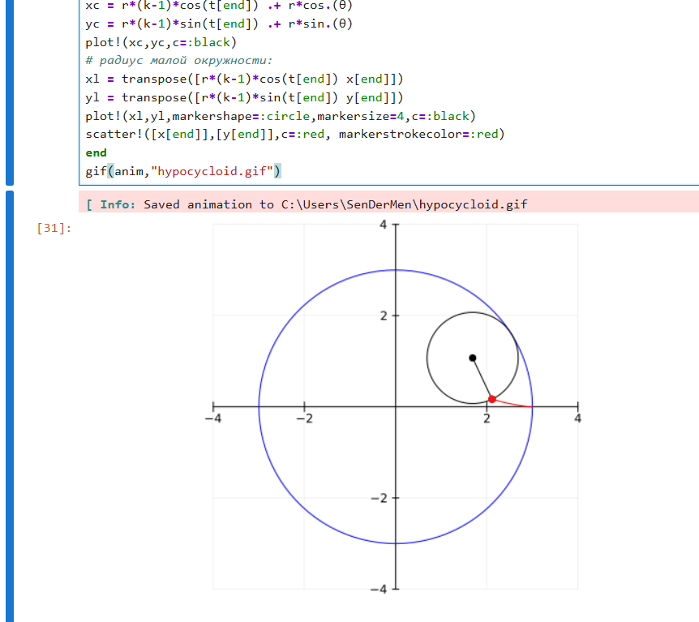

Анимация гипоциклоиды